# Risk Factor Analysis

## Outcome Variable

**Outcome Variable:** haz

## Predictor Variables

**Intervention Variable:** hhwealth_quart

**Adjustment Set:**

- arm
- sex
- W_mage
- meducyrs
- feducyrs
- W_gagebrth
- W_birthwt
- W_birthlen
- W_nchldlt5
- W_parity
- delta_W_mage
- delta_meducyrs
- delta_feducyrs
- delta_W_gagebrth
- delta_W_birthwt
- delta_W_birthlen
- delta_W_nchldlt5
- delta_W_parity

## Stratifying Variables

The analysis was stratified on these variable(s):

- agecat
- studyid
- country

## Data Summary

| agecat | studyid | country | hhwealth_quart | n_cell | n | outcome_variable |
| --- | --- | --- | --- | --- | --- | --- |
| Birth | CMC-V-BCS-2002 | INDIA | Wealth Q4 | 32 | 92 | haz |
| Birth | CMC-V-BCS-2002 | INDIA | Wealth Q1 | 15 | 92 | haz |
| Birth | CMC-V-BCS-2002 | INDIA | Wealth Q2 | 20 | 92 | haz |
| Birth | CMC-V-BCS-2002 | INDIA | Wealth Q3 | 25 | 92 | haz |
| Birth | COHORTS | GUATEMALA | Wealth Q4 | 293 | 816 | haz |
| Birth | COHORTS | GUATEMALA | Wealth Q1 | 157 | 816 | haz |
| Birth | COHORTS | GUATEMALA | Wealth Q2 | 161 | 816 | haz |
| Birth | COHORTS | GUATEMALA | Wealth Q3 | 205 | 816 | haz |
| Birth | COHORTS | PHILIPPINES | Wealth Q4 | 842 | 3049 | haz |
| Birth | COHORTS | PHILIPPINES | Wealth Q1 | 687 | 3049 | haz |
| Birth | COHORTS | PHILIPPINES | Wealth Q2 | 538 | 3049 | haz |
| Birth | COHORTS | PHILIPPINES | Wealth Q3 | 982 | 3049 | haz |
| Birth | CONTENT | PERU | Wealth Q4 | 0 | 2 | haz |
| Birth | CONTENT | PERU | Wealth Q1 | 0 | 2 | haz |
| Birth | CONTENT | PERU | Wealth Q2 | 1 | 2 | haz |
| Birth | CONTENT | PERU | Wealth Q3 | 1 | 2 | haz |
| Birth | GMS-Nepal | NEPAL | Wealth Q4 | 173 | 696 | haz |
| Birth | GMS-Nepal | NEPAL | Wealth Q1 | 175 | 696 | haz |
| Birth | GMS-Nepal | NEPAL | Wealth Q2 | 174 | 696 | haz |
| Birth | GMS-Nepal | NEPAL | Wealth Q3 | 174 | 696 | haz |
| Birth | IRC | INDIA | Wealth Q4 | 91 | 388 | haz |
| Birth | IRC | INDIA | Wealth Q1 | 98 | 388 | haz |
| Birth | IRC | INDIA | Wealth Q2 | 99 | 388 | haz |
| Birth | IRC | INDIA | Wealth Q3 | 100 | 388 | haz |
| Birth | JiVitA-3 | BANGLADESH | Wealth Q4 | 5278 | 22434 | haz |
| Birth | JiVitA-3 | BANGLADESH | Wealth Q1 | 5772 | 22434 | haz |
| Birth | JiVitA-3 | BANGLADESH | Wealth Q2 | 5701 | 22434 | haz |
| Birth | JiVitA-3 | BANGLADESH | Wealth Q3 | 5683 | 22434 | haz |
| Birth | JiVitA-4 | BANGLADESH | Wealth Q4 | 654 | 2820 | haz |
| Birth | JiVitA-4 | BANGLADESH | Wealth Q1 | 685 | 2820 | haz |

[output cut: 178 more lines]

The following strata were considered:

- agecat: 24 months, studyid: CMC-V-BCS-2002, country: INDIA
- agecat: 24 months, studyid: COHORTS, country: GUATEMALA
- agecat: 24 months, studyid: COHORTS, country: PHILIPPINES
- agecat: 24 months, studyid: CONTENT, country: PERU
- agecat: 24 months, studyid: GMS-Nepal, country: NEPAL
- agecat: 24 months, studyid: IRC, country: INDIA
- agecat: 24 months, studyid: JiVitA-3, country: BANGLADESH
- agecat: 24 months, studyid: JiVitA-4, country: BANGLADESH
- agecat: 24 months, studyid: LCNI-5, country: MALAWI
- agecat: 24 months, studyid: MAL-ED, country: BANGLADESH
- agecat: 24 months, studyid: MAL-ED, country: BRAZIL
- agecat: 24 months, studyid: MAL-ED, country: INDIA
- agecat: 24 months, studyid: MAL-ED, country: NEPAL
- agecat: 24 months, studyid: MAL-ED, country: PERU
- agecat: 24 months, studyid: MAL-ED, country: SOUTH AFRICA
- agecat: 24 months, studyid: MAL-ED, country: TANZANIA, UNITED REPUBLIC OF
- agecat: 24 months, studyid: PROVIDE, country: BANGLADESH
- agecat: 24 months, studyid: TanzaniaChild2, country: TANZANIA, UNITED REPUBLIC OF
- agecat: 6 months, studyid: CMC-V-BCS-2002, country: INDIA
- agecat: 6 months, studyid: COHORTS, country: GUATEMALA
- agecat: 6 months, studyid: COHORTS, country: PHILIPPINES
- agecat: 6 months, studyid: CONTENT, country: PERU
- agecat: 6 months, studyid: GMS-Nepal, country: NEPAL
- agecat: 6 months, studyid: IRC, country: INDIA
- agecat: 6 months, studyid: JiVitA-3, country: BANGLADESH
- agecat: 6 months, studyid: JiVitA-4, country: BANGLADESH
- agecat: 6 months, studyid: LCNI-5, country: MALAWI
- agecat: 6 months, studyid: MAL-ED, country: BANGLADESH
- agecat: 6 months, studyid: MAL-ED, country: BRAZIL
- agecat: 6 months, studyid: MAL-ED, country: INDIA
- agecat: 6 months, studyid: MAL-ED, country: NEPAL
- agecat: 6 months, studyid: MAL-ED, country: PERU
- agecat: 6 months, studyid: MAL-ED, country: SOUTH AFRICA
- agecat: 6 months, studyid: MAL-ED, country: TANZANIA, UNITED REPUBLIC OF
- agecat: 6 months, studyid: PROVIDE, country: BANGLADESH
- agecat: 6 months, studyid: TanzaniaChild2, country: TANZANIA, UNITED REPUBLIC OF
- agecat: Birth, studyid: CMC-V-BCS-2002, country: INDIA
- agecat: Birth, studyid: COHORTS, country: GUATEMALA
- agecat: Birth, studyid: COHORTS, country: PHILIPPINES
- agecat: Birth, studyid: CONTENT, country: PERU
- agecat: Birth, studyid: GMS-Nepal, country: NEPAL
- agecat: Birth, studyid: IRC, country: INDIA
- agecat: Birth, studyid: JiVitA-3, country: BANGLADESH
- agecat: Birth, studyid: JiVitA-4, country: BANGLADESH
- agecat: Birth, studyid: MAL-ED, country: BANGLADESH
- agecat: Birth, studyid: MAL-ED, country: BRAZIL
- agecat: Birth, studyid: MAL-ED, country: INDIA
- agecat: Birth, studyid: MAL-ED, country: NEPAL
- agecat: Birth, studyid: MAL-ED, country: PERU
- agecat: Birth, studyid: MAL-ED, country: SOUTH AFRICA
- agecat: Birth, studyid: MAL-ED, country: TANZANIA, UNITED REPUBLIC OF
- agecat: Birth, studyid: PROVIDE, country: BANGLADESH

### Dropped Strata

Some strata were dropped due to rare outcomes:

- agecat: Birth, studyid: CONTENT, country: PERU
- agecat: Birth, studyid: MAL-ED, country: NEPAL
- agecat: 24 months, studyid: TanzaniaChild2, country: TANZANIA, UNITED REPUBLIC OF

## Methods Detail

We’re interested in the causal parameters $E[Y_a]$ for all values of $a \in \mathcal{A}$. These parameters represent the mean outcome if, possibly contrary to fact, we intervened to set all units to have $A=a$. Under the randomization and positivity assumptions, these are identified by the statistical parameters $\psi_a=E_W[E_{Y|A,W}(Y|A=a,W)]$. In addition, we’re interested in the mean of $Y$, $E[Y]$ under no intervention (the observed mean). We will estimate these parameters by using SuperLearner to fit the relevant likelihood factors – $E_{Y|A,W}(Y|A=a,W)$ and $p(A=a|W)$, and then updating our likelihood fit using a joint TMLE.

For unadjusted analyses ($W=\{\}$), initial likelihoods were estimated using Lrnr_glm to estimate the simple $E(Y|A)$ and Lrnr_mean to estimate $p(A)$. For adjusted analyses, a small library containing Lrnr_glmnet, Lrnr_xgboost, and Lrnr_mean was used.

Having estimated these parameters, we will then use the delta method to estimate relative risks and attributable risks relative to a prespecified baseline level of $A$.

# Results Detail

## Results Plots

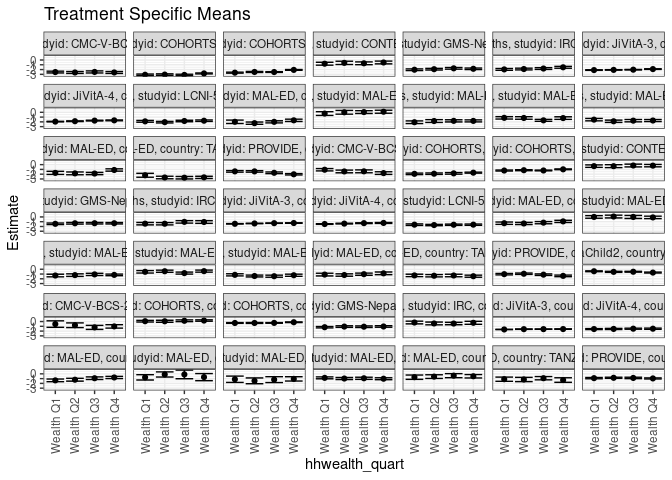

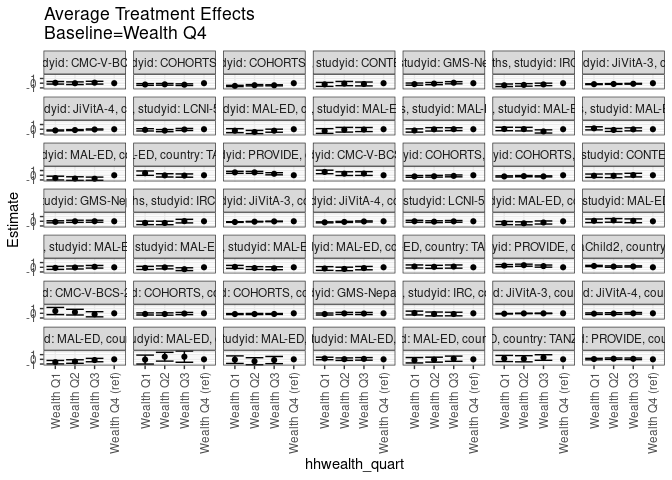

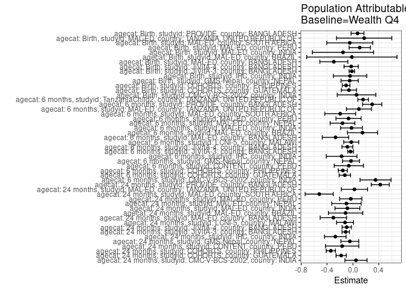

## Results Table

### Parameter: TSM

| agecat | studyid | country | intervention_level | baseline_level | estimate | ci_lower | ci_upper |
| --- | --- | --- | --- | --- | --- | --- | --- |
| Birth | CMC-V-BCS-2002 | INDIA | Wealth Q4 | NA | -1.0175030 | -1.3702604 | -0.6647455 |
| Birth | CMC-V-BCS-2002 | INDIA | Wealth Q1 | NA | -0.5282617 | -1.2055618 | 0.1490384 |
| Birth | CMC-V-BCS-2002 | INDIA | Wealth Q2 | NA | -0.7698828 | -1.2590342 | -0.2807314 |
| Birth | CMC-V-BCS-2002 | INDIA | Wealth Q3 | NA | -1.2225153 | -1.6454335 | -0.7995970 |
| Birth | COHORTS | GUATEMALA | Wealth Q4 | NA | 0.2065939 | 0.0623169 | 0.3508709 |
| Birth | COHORTS | GUATEMALA | Wealth Q1 | NA | 0.0696080 | -0.0999974 | 0.2392134 |
| Birth | COHORTS | GUATEMALA | Wealth Q2 | NA | 0.0582332 | -0.1494414 | 0.2659077 |
| Birth | COHORTS | GUATEMALA | Wealth Q3 | NA | 0.1588885 | -0.0218480 | 0.3396250 |
| Birth | COHORTS | PHILIPPINES | Wealth Q4 | NA | -0.1442727 | -0.2135522 | -0.0749933 |
| Birth | COHORTS | PHILIPPINES | Wealth Q1 | NA | -0.3033785 | -0.3858113 | -0.2209457 |
| Birth | COHORTS | PHILIPPINES | Wealth Q2 | NA | -0.2982475 | -0.3974917 | -0.1990034 |
| Birth | COHORTS | PHILIPPINES | Wealth Q3 | NA | -0.2841841 | -0.3533303 | -0.2150379 |
| Birth | GMS-Nepal | NEPAL | Wealth Q4 | NA | -1.0352658 | -1.1934798 | -0.8770518 |
| Birth | GMS-Nepal | NEPAL | Wealth Q1 | NA | -1.1872373 | -1.3330273 | -1.0414473 |
| Birth | GMS-Nepal | NEPAL | Wealth Q2 | NA | -1.0535525 | -1.2140807 | -0.8930244 |
| Birth | GMS-Nepal | NEPAL | Wealth Q3 | NA | -1.0800888 | -1.2414420 | -0.9187357 |
| Birth | IRC | INDIA | Wealth Q4 | NA | -0.2640982 | -0.5812966 | 0.0531001 |
| Birth | IRC | INDIA | Wealth Q1 | NA | -0.2041520 | -0.4845424 | 0.0762385 |
| Birth | IRC | INDIA | Wealth Q2 | NA | -0.3996861 | -0.6912513 | -0.1081209 |
| Birth | IRC | INDIA | Wealth Q3 | NA | -0.4170432 | -0.6690060 | -0.1650805 |
| Birth | JiVitA-3 | BANGLADESH | Wealth Q4 | NA | -1.5729638 | -1.6211495 | -1.5247781 |
| Birth | JiVitA-3 | BANGLADESH | Wealth Q1 | NA | -1.6584433 | -1.6937338 | -1.6231528 |
| Birth | JiVitA-3 | BANGLADESH | Wealth Q2 | NA | -1.5962865 | -1.6310623 | -1.5615107 |
| Birth | JiVitA-3 | BANGLADESH | Wealth Q3 | NA | -1.5880883 | -1.6201266 | -1.5560499 |
| Birth | JiVitA-4 | BANGLADESH | Wealth Q4 | NA | -1.4974657 | -1.6208841 | -1.3740472 |
| Birth | JiVitA-4 | BANGLADESH | Wealth Q1 | NA | -1.5706111 | -1.6734244 | -1.4677978 |
| Birth | JiVitA-4 | BANGLADESH | Wealth Q2 | NA | -1.5478628 | -1.6685019 | -1.4272238 |
| Birth | JiVitA-4 | BANGLADESH | Wealth Q3 | NA | -1.4957511 | -1.6073985 | -1.3841037 |
| Birth | MAL-ED | BANGLADESH | Wealth Q4 | NA | -0.7583276 | -0.9903983 | -0.5262569 |
| Birth | MAL-ED | BANGLADESH | Wealth Q1 | NA | -1.3635176 | -1.6458434 | -1.0811918 |

[output cut: 166 more lines]

### Parameter: E(Y)

| agecat | studyid | country | intervention_level | baseline_level | estimate | ci_lower | ci_upper |
| --- | --- | --- | --- | --- | --- | --- | --- |
| Birth | CMC-V-BCS-2002 | INDIA | NA | NA | -0.9611957 | -1.1776967 | -0.7446946 |
| Birth | COHORTS | GUATEMALA | NA | NA | 0.1452941 | 0.0610109 | 0.2295774 |
| Birth | COHORTS | PHILIPPINES | NA | NA | -0.2491505 | -0.2881717 | -0.2101294 |
| Birth | GMS-Nepal | NEPAL | NA | NA | -1.0851580 | -1.1651811 | -1.0051350 |
| Birth | IRC | INDIA | NA | NA | -0.3080412 | -0.4687931 | -0.1472894 |
| Birth | JiVitA-3 | BANGLADESH | NA | NA | -1.5897094 | -1.6089856 | -1.5704331 |
| Birth | JiVitA-4 | BANGLADESH | NA | NA | -1.5236135 | -1.5727559 | -1.4744711 |
| Birth | MAL-ED | BANGLADESH | NA | NA | -1.0530516 | -1.1896058 | -0.9164975 |
| Birth | MAL-ED | BRAZIL | NA | NA | -0.6963333 | -0.9881882 | -0.4044785 |
| Birth | MAL-ED | INDIA | NA | NA | -1.2070732 | -1.5254820 | -0.8886644 |
| Birth | MAL-ED | PERU | NA | NA | -0.9141395 | -1.0364098 | -0.7918693 |
| Birth | MAL-ED | SOUTH AFRICA | NA | NA | -0.5523958 | -0.7550074 | -0.3497843 |
| Birth | MAL-ED | TANZANIA, UNITED REPUBLIC OF | NA | NA | -1.1225000 | -1.3335666 | -0.9114334 |
| Birth | PROVIDE | BANGLADESH | NA | NA | -0.8851020 | -0.9601332 | -0.8100709 |
| 6 months | CMC-V-BCS-2002 | INDIA | NA | NA | -1.4234508 | -1.5645974 | -1.2823042 |
| 6 months | COHORTS | GUATEMALA | NA | NA | -1.8112324 | -1.8807284 | -1.7417365 |
| 6 months | COHORTS | PHILIPPINES | NA | NA | -1.1405724 | -1.1824954 | -1.0986493 |
| 6 months | CONTENT | PERU | NA | NA | -0.2785256 | -0.4098735 | -0.1471776 |
| 6 months | GMS-Nepal | NEPAL | NA | NA | -1.3508392 | -1.4290633 | -1.2726152 |
| 6 months | IRC | INDIA | NA | NA | -1.2344062 | -1.3658524 | -1.1029600 |
| 6 months | JiVitA-3 | BANGLADESH | NA | NA | -1.3132090 | -1.3363486 | -1.2900693 |
| 6 months | JiVitA-4 | BANGLADESH | NA | NA | -1.3440477 | -1.3813060 | -1.3067894 |
| 6 months | LCNI-5 | MALAWI | NA | NA | -1.6426961 | -1.7120603 | -1.5733318 |
| 6 months | MAL-ED | BANGLADESH | NA | NA | -1.2026806 | -1.3203025 | -1.0850586 |
| 6 months | MAL-ED | BRAZIL | NA | NA | 0.0475758 | -0.0963508 | 0.1915023 |
| 6 months | MAL-ED | INDIA | NA | NA | -1.2070638 | -1.3255909 | -1.0885368 |
| 6 months | MAL-ED | NEPAL | NA | NA | -0.5615819 | -0.6741832 | -0.4489807 |
| 6 months | MAL-ED | PERU | NA | NA | -1.3248549 | -1.4336721 | -1.2160378 |
| 6 months | MAL-ED | SOUTH AFRICA | NA | NA | -1.0547925 | -1.1843544 | -0.9252306 |
| 6 months | MAL-ED | TANZANIA, UNITED REPUBLIC OF | NA | NA | -1.3687449 | -1.4907629 | -1.2467270 |
| 6 months | PROVIDE | BANGLADESH | NA | NA | -1.0916915 | -1.1661176 | -1.0172654 |
| 6 months | TanzaniaChild2 | TANZANIA, UNITED REPUBLIC OF | NA | NA | -0.5442232 | -0.5932373 | -0.4952090 |
| 24 months | CMC-V-BCS-2002 | INDIA | NA | NA | -2.5588679 | -2.6583730 | -2.4593629 |
| 24 months | COHORTS | GUATEMALA | NA | NA | -2.9893430 | -3.0546993 | -2.9239867 |
| 24 months | COHORTS | PHILIPPINES | NA | NA | -2.4141145 | -2.4590818 | -2.3691473 |
| 24 months | CONTENT | PERU | NA | NA | -0.6868598 | -0.8388476 | -0.5348719 |
| 24 months | GMS-Nepal | NEPAL | NA | NA | -1.8874180 | -1.9728588 | -1.8019773 |
| 24 months | IRC | INDIA | NA | NA | -1.7987775 | -1.8923914 | -1.7051636 |
| 24 months | JiVitA-3 | BANGLADESH | NA | NA | -2.0135591 | -2.0412422 | -1.9858759 |
| 24 months | JiVitA-4 | BANGLADESH | NA | NA | -1.7803708 | -1.8158650 | -1.7448765 |
| 24 months | LCNI-5 | MALAWI | NA | NA | -1.8822648 | -1.9637218 | -1.8008078 |
| 24 months | MAL-ED | BANGLADESH | NA | NA | -1.9783962 | -2.1050210 | -1.8517715 |
| 24 months | MAL-ED | BRAZIL | NA | NA | 0.0061144 | -0.1625850 | 0.1748138 |
| 24 months | MAL-ED | INDIA | NA | NA | -1.8861894 | -2.0110006 | -1.7613783 |
| 24 months | MAL-ED | NEPAL | NA | NA | -1.3075877 | -1.4270718 | -1.1881037 |
| 24 months | MAL-ED | PERU | NA | NA | -1.7524710 | -1.8736426 | -1.6312994 |
| 24 months | MAL-ED | SOUTH AFRICA | NA | NA | -1.6450595 | -1.7797240 | -1.5103950 |
| 24 months | MAL-ED | TANZANIA, UNITED REPUBLIC OF | NA | NA | -2.6455607 | -2.7807256 | -2.5103959 |
| 24 months | PROVIDE | BANGLADESH | NA | NA | -1.6024221 | -1.6857420 | -1.5191023 |

### Parameter: ATE

| agecat | studyid | country | intervention_level | baseline_level | estimate | ci_lower | ci_upper |
| --- | --- | --- | --- | --- | --- | --- | --- |
| Birth | CMC-V-BCS-2002 | INDIA | Wealth Q4 | Wealth Q4 | 0.0000000 | 0.0000000 | 0.0000000 |
| Birth | CMC-V-BCS-2002 | INDIA | Wealth Q1 | Wealth Q4 | 0.4892412 | -0.2745635 | 1.2530459 |
| Birth | CMC-V-BCS-2002 | INDIA | Wealth Q2 | Wealth Q4 | 0.2476202 | -0.3565789 | 0.8518192 |
| Birth | CMC-V-BCS-2002 | INDIA | Wealth Q3 | Wealth Q4 | -0.2050123 | -0.7555511 | 0.3455264 |
| Birth | COHORTS | GUATEMALA | Wealth Q4 | Wealth Q4 | 0.0000000 | 0.0000000 | 0.0000000 |
| Birth | COHORTS | GUATEMALA | Wealth Q1 | Wealth Q4 | -0.1369859 | -0.3598279 | 0.0858561 |
| Birth | COHORTS | GUATEMALA | Wealth Q2 | Wealth Q4 | -0.1483607 | -0.4011967 | 0.1044752 |
| Birth | COHORTS | GUATEMALA | Wealth Q3 | Wealth Q4 | -0.0477054 | -0.2790106 | 0.1835998 |
| Birth | COHORTS | PHILIPPINES | Wealth Q4 | Wealth Q4 | 0.0000000 | 0.0000000 | 0.0000000 |
| Birth | COHORTS | PHILIPPINES | Wealth Q1 | Wealth Q4 | -0.1591058 | -0.2649703 | -0.0532412 |
| Birth | COHORTS | PHILIPPINES | Wealth Q2 | Wealth Q4 | -0.1539748 | -0.2731897 | -0.0347599 |
| Birth | COHORTS | PHILIPPINES | Wealth Q3 | Wealth Q4 | -0.1399113 | -0.2357167 | -0.0441060 |
| Birth | GMS-Nepal | NEPAL | Wealth Q4 | Wealth Q4 | 0.0000000 | 0.0000000 | 0.0000000 |
| Birth | GMS-Nepal | NEPAL | Wealth Q1 | Wealth Q4 | -0.1519715 | -0.3631372 | 0.0591943 |
| Birth | GMS-Nepal | NEPAL | Wealth Q2 | Wealth Q4 | -0.0182867 | -0.2390930 | 0.2025195 |
| Birth | GMS-Nepal | NEPAL | Wealth Q3 | Wealth Q4 | -0.0448230 | -0.2664720 | 0.1768259 |
| Birth | IRC | INDIA | Wealth Q4 | Wealth Q4 | 0.0000000 | 0.0000000 | 0.0000000 |
| Birth | IRC | INDIA | Wealth Q1 | Wealth Q4 | 0.0599462 | -0.3427092 | 0.4626017 |
| Birth | IRC | INDIA | Wealth Q2 | Wealth Q4 | -0.1355879 | -0.5445074 | 0.2733315 |
| Birth | IRC | INDIA | Wealth Q3 | Wealth Q4 | -0.1529450 | -0.5368720 | 0.2309819 |
| Birth | JiVitA-3 | BANGLADESH | Wealth Q4 | Wealth Q4 | 0.0000000 | 0.0000000 | 0.0000000 |
| Birth | JiVitA-3 | BANGLADESH | Wealth Q1 | Wealth Q4 | -0.0854795 | -0.1400337 | -0.0309253 |
| Birth | JiVitA-3 | BANGLADESH | Wealth Q2 | Wealth Q4 | -0.0233227 | -0.0774292 | 0.0307839 |
| Birth | JiVitA-3 | BANGLADESH | Wealth Q3 | Wealth Q4 | -0.0151244 | -0.0683533 | 0.0381044 |
| Birth | JiVitA-4 | BANGLADESH | Wealth Q4 | Wealth Q4 | 0.0000000 | 0.0000000 | 0.0000000 |
| Birth | JiVitA-4 | BANGLADESH | Wealth Q1 | Wealth Q4 | -0.0731454 | -0.2334456 | 0.0871548 |
| Birth | JiVitA-4 | BANGLADESH | Wealth Q2 | Wealth Q4 | -0.0503972 | -0.2236739 | 0.1228796 |
| Birth | JiVitA-4 | BANGLADESH | Wealth Q3 | Wealth Q4 | 0.0017145 | -0.1640772 | 0.1675063 |
| Birth | MAL-ED | BANGLADESH | Wealth Q4 | Wealth Q4 | 0.0000000 | 0.0000000 | 0.0000000 |
| Birth | MAL-ED | BANGLADESH | Wealth Q1 | Wealth Q4 | -0.6051900 | -0.9725474 | -0.2378325 |

[output cut: 166 more lines]

### Parameter: PAR

| agecat | studyid | country | intervention_level | baseline_level | estimate | ci_lower | ci_upper |
| --- | --- | --- | --- | --- | --- | --- | --- |
| Birth | CMC-V-BCS-2002 | INDIA | Wealth Q4 | NA | 0.0563073 | -0.2422908 | 0.3549054 |
| Birth | COHORTS | GUATEMALA | Wealth Q4 | NA | -0.0612998 | -0.1787875 | 0.0561880 |
| Birth | COHORTS | PHILIPPINES | Wealth Q4 | NA | -0.1048778 | -0.1642464 | -0.0455092 |
| Birth | GMS-Nepal | NEPAL | Wealth Q4 | NA | -0.0498922 | -0.1836736 | 0.0838892 |
| Birth | IRC | INDIA | Wealth Q4 | NA | -0.0439430 | -0.3018999 | 0.2140139 |
| Birth | JiVitA-3 | BANGLADESH | Wealth Q4 | NA | -0.0167456 | -0.0588515 | 0.0253604 |
| Birth | JiVitA-4 | BANGLADESH | Wealth Q4 | NA | -0.0261478 | -0.1366328 | 0.0843372 |
| Birth | MAL-ED | BANGLADESH | Wealth Q4 | NA | -0.2947240 | -0.5110808 | -0.0783673 |
| Birth | MAL-ED | BRAZIL | Wealth Q4 | NA | -0.0161584 | -0.7144666 | 0.6821498 |
| Birth | MAL-ED | INDIA | Wealth Q4 | NA | -0.1533232 | -0.6267868 | 0.3201405 |
| Birth | MAL-ED | PERU | Wealth Q4 | NA | 0.1058106 | -0.0583734 | 0.2699946 |
| Birth | MAL-ED | SOUTH AFRICA | Wealth Q4 | NA | -0.0482770 | -0.4043828 | 0.3078289 |
| Birth | MAL-ED | TANZANIA, UNITED REPUBLIC OF | Wealth Q4 | NA | 0.1745029 | -0.2528746 | 0.6018805 |
| Birth | PROVIDE | BANGLADESH | Wealth Q4 | NA | 0.0722218 | -0.0270033 | 0.1714470 |
| 6 months | CMC-V-BCS-2002 | INDIA | Wealth Q4 | NA | 0.3501953 | 0.1105858 | 0.5898048 |
| 6 months | COHORTS | GUATEMALA | Wealth Q4 | NA | -0.1241274 | -0.2123309 | -0.0359240 |
| 6 months | COHORTS | PHILIPPINES | Wealth Q4 | NA | -0.1562057 | -0.2258415 | -0.0865699 |
| 6 months | CONTENT | PERU | Wealth Q4 | NA | -0.0633505 | -0.2893080 | 0.1626071 |
| 6 months | GMS-Nepal | NEPAL | Wealth Q4 | NA | -0.0294085 | -0.1602908 | 0.1014739 |
| 6 months | IRC | INDIA | Wealth Q4 | NA | -0.1738086 | -0.4108197 | 0.0632025 |
| 6 months | JiVitA-3 | BANGLADESH | Wealth Q4 | NA | -0.0358782 | -0.0798940 | 0.0081376 |
| 6 months | JiVitA-4 | BANGLADESH | Wealth Q4 | NA | -0.0850529 | -0.1690774 | -0.0010284 |
| 6 months | LCNI-5 | MALAWI | Wealth Q4 | NA | -0.0258907 | -0.1416477 | 0.0898663 |
| 6 months | MAL-ED | BANGLADESH | Wealth Q4 | NA | -0.2694524 | -0.4733829 | -0.0655219 |
| 6 months | MAL-ED | BRAZIL | Wealth Q4 | NA | 0.1484509 | -0.0839124 | 0.3808141 |
| 6 months | MAL-ED | INDIA | Wealth Q4 | NA | -0.0213314 | -0.1898911 | 0.1472282 |
| 6 months | MAL-ED | NEPAL | Wealth Q4 | NA | -0.1602652 | -0.3514016 | 0.0308713 |
| 6 months | MAL-ED | PERU | Wealth Q4 | NA | -0.0676179 | -0.2619908 | 0.1267551 |
| 6 months | MAL-ED | SOUTH AFRICA | Wealth Q4 | NA | -0.1961281 | -0.4347597 | 0.0425036 |
| 6 months | MAL-ED | TANZANIA, UNITED REPUBLIC OF | Wealth Q4 | NA | 0.0933435 | -0.1000563 | 0.2867433 |
| 6 months | PROVIDE | BANGLADESH | Wealth Q4 | NA | 0.2985959 | 0.1501992 | 0.4469927 |
| 6 months | TanzaniaChild2 | TANZANIA, UNITED REPUBLIC OF | Wealth Q4 | NA | 0.1579470 | 0.0766611 | 0.2392329 |
| 24 months | CMC-V-BCS-2002 | INDIA | Wealth Q4 | NA | 0.0478999 | -0.1231944 | 0.2189942 |
| 24 months | COHORTS | GUATEMALA | Wealth Q4 | NA | -0.1802710 | -0.2600688 | -0.1004732 |
| 24 months | COHORTS | PHILIPPINES | Wealth Q4 | NA | -0.3412117 | -0.4127199 | -0.2697036 |
| 24 months | CONTENT | PERU | Wealth Q4 | NA | -0.1665192 | -0.4244008 | 0.0913623 |
| 24 months | GMS-Nepal | NEPAL | Wealth Q4 | NA | -0.0470154 | -0.1844068 | 0.0903759 |
| 24 months | IRC | INDIA | Wealth Q4 | NA | -0.2719220 | -0.4388271 | -0.1050169 |
| 24 months | JiVitA-3 | BANGLADESH | Wealth Q4 | NA | -0.1104954 | -0.1674768 | -0.0535140 |
| 24 months | JiVitA-4 | BANGLADESH | Wealth Q4 | NA | -0.0953935 | -0.1670143 | -0.0237727 |
| 24 months | LCNI-5 | MALAWI | Wealth Q4 | NA | -0.1214210 | -0.2522321 | 0.0093900 |
| 24 months | MAL-ED | BANGLADESH | Wealth Q4 | NA | -0.3020003 | -0.5060412 | -0.0979594 |
| 24 months | MAL-ED | BRAZIL | Wealth Q4 | NA | -0.1124383 | -0.3779586 | 0.1530821 |
| 24 months | MAL-ED | INDIA | Wealth Q4 | NA | -0.0846393 | -0.2768533 | 0.1075747 |
| 24 months | MAL-ED | NEPAL | Wealth Q4 | NA | -0.0995339 | -0.3267823 | 0.1277144 |
| 24 months | MAL-ED | PERU | Wealth Q4 | NA | -0.0323179 | -0.2043832 | 0.1397473 |
| 24 months | MAL-ED | SOUTH AFRICA | Wealth Q4 | NA | -0.5208058 | -0.7378985 | -0.3037131 |
| 24 months | MAL-ED | TANZANIA, UNITED REPUBLIC OF | Wealth Q4 | NA | 0.0242557 | -0.1783902 | 0.2269016 |
| 24 months | PROVIDE | BANGLADESH | Wealth Q4 | NA | 0.4236813 | 0.2846884 | 0.5626742 |